# Report on the stochastic model for Georgia with the inclusion of a latent trend in transmission rate

Andrew Tredennick

02 June, 2020

## Overview

The current *Georgia stochostic model* of COVID-19 tranmission incorporates a metric of human movement ($\phi(t)$) that moderates the baseline tranmission rate ($\beta$): $\beta(t) = \phi(t)\beta$. This formulation is meant to represent the impact of social distancing. Social distancing, while powerful, is not the only practice that can reduce transmission. Other practices, such as wearing face coverings, maintaining social distance in public spaces, and enhanced cleaning practices, can also reduce transmission. These practices are difficult to quantify in data and, in turn, are difficult to model explicitly. Nonetheless, we expect that mobility data will become less informative of transmission over time and that other practices will play a larger role.

Here I report on models fit to the most recent data and projections from the fitted models. Note that we are only longer fitting to hospitalization data because it is pretty unreliable.

## Results

### Estimated latent trend in tranmission

The MLE parameters lead to the following latent trend.

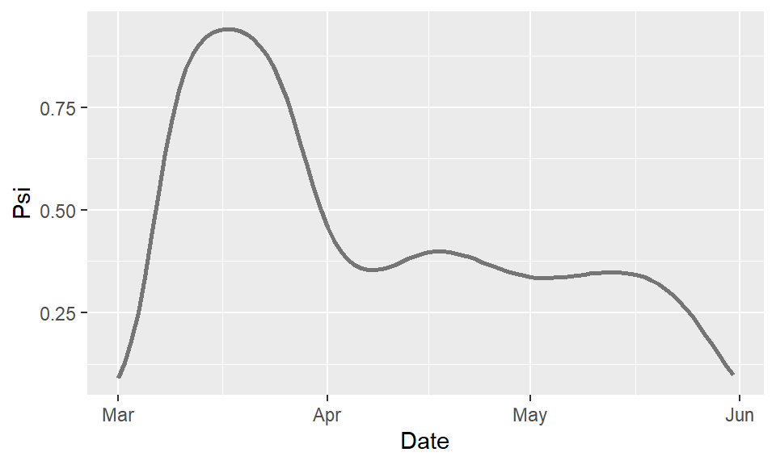

### MLE parameters estimates

| MLE set | LogLik | LogLik_SE | beta_s | frac_dead | theta_cases | theta_deaths | sigma_dw |
| --- | --- | --- | --- | --- | --- | --- | --- |
| 1 | -870.83 | 0.12 | 0.78 | 0.50 | 6.76 | 2.82 | 0.00 |
| 2 | -871.23 | 0.16 | 0.73 | 0.53 | 7.05 | 2.39 | 0.00 |
| 3 | -871.82 | 0.06 | 0.73 | 0.47 | 7.60 | 2.52 | 0.05 |
| 4 | -871.83 | 0.12 | 0.77 | 0.57 | 6.99 | 2.22 | 0.01 |
| 5 | -872.00 | 0.14 | 0.85 | 0.48 | 7.12 | 2.25 | 0.06 |
| 6 | -872.01 | 0.15 | 0.82 | 0.56 | 8.13 | 2.50 | 0.00 |
| 7 | -872.14 | 0.12 | 0.69 | 0.46 | 7.33 | 2.47 | 0.02 |
| 8 | -872.22 | 0.42 | 0.71 | 0.49 | 7.49 | 2.40 | 0.09 |
| 9 | -872.35 | 0.06 | 0.80 | 0.50 | 6.60 | 2.07 | 0.05 |
| 10 | -872.37 | 0.16 | 0.76 | 0.47 | 7.86 | 2.49 | 0.00 |
| 11 | -872.55 | 0.05 | 0.79 | 0.50 | 7.43 | 2.51 | 0.00 |

### Scenario projections

I excluded all counter-factuals. Here I list the scenarios and how they were implemented.

1. Increase social distancing: $\phi \rightarrow 0.3$ over the course of 7 days and remains there; $\psi$ is set to the mean of the last thirty trend estimates.
2. Status quo: $\phi$ remains at last observed value; $\psi$ is set to the mean of the last thirty trend estimates.
3. Return to normal: $\phi \rightarrow 1$ over the course of 7 days and remains there; $\psi$ is set to the mean of the last thirty trend estimates.

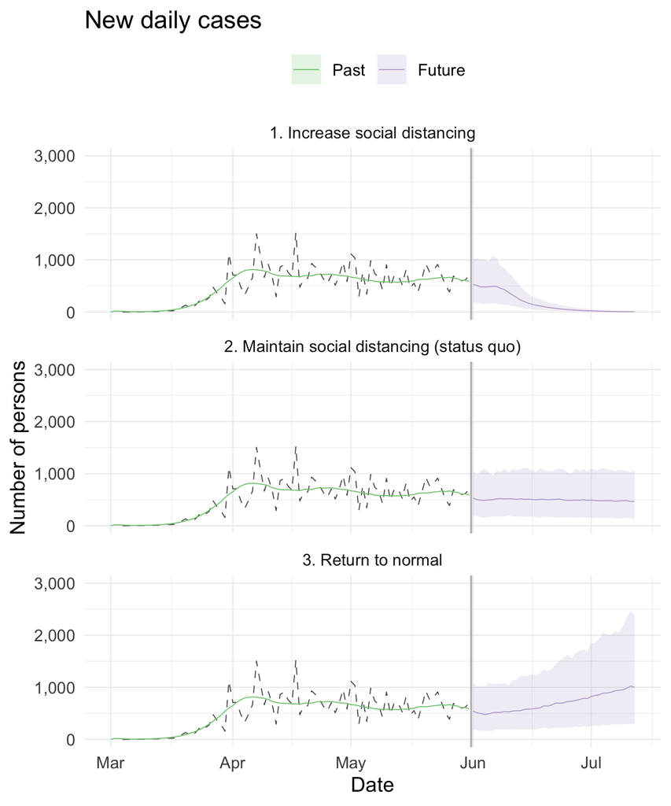

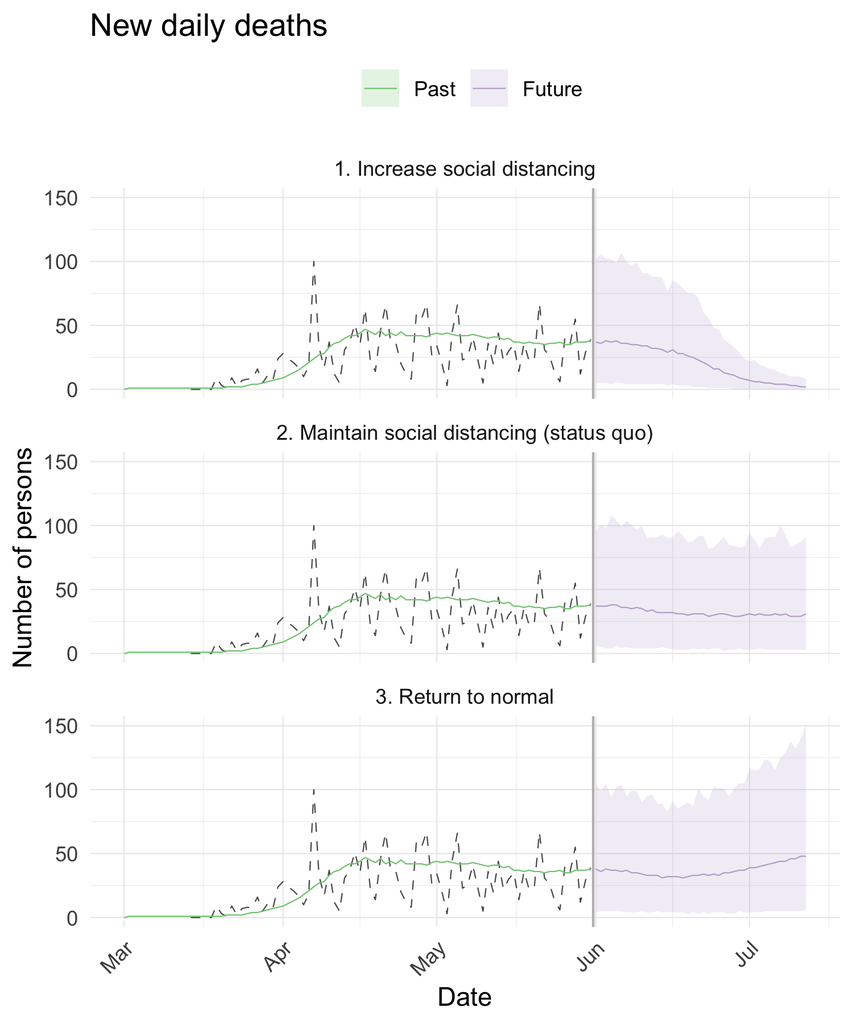

## Conclusions

Overall, the fits are very good and the projections are reasonable. I am a little worried about the fragility of projection with the mean of the latent trend over the last 30 days. Time will tell on that front, but it might also be a good idea to “go back in time” and see how well that assumption works.

# Appendix

## Implementation

We currently model the force of infection ($f$) at time $t$ as:

$$f(t) = \phi(t)\frac{\beta}{N} (I(t)),$$

where, for simplicity, $I$ stands for all infectious individuals at time $t$. The mobility index $\phi$ looks like this:

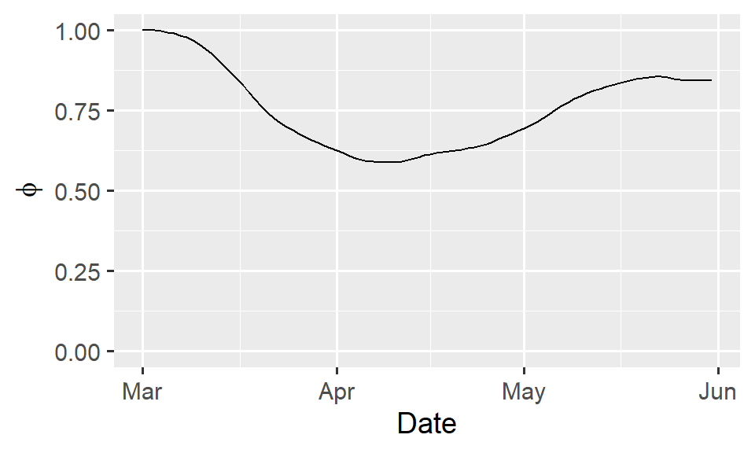

I proposed to add a temporal basis function to incorporate additional tranmission reduction over time that we cannot observe. Let the new temporal term be $\psi$, which is modeled as:

$$\text{logit}\left(\psi(t)\right) = \sum_{i=1}^K q_i \xi_{i_t},$$

where $K$ is the number of knots, $\mathbf{q}$ is a vector of spline coefficients (to be fitted), and $\mathbf{\xi}$ is a matrix basis functions. I define the number of knots ($K$) as the number of days in the data set divided by 7 (so, one knot per week). Note the logit transformation to go from the linear scale to the 0 - 1 scale. Thus, $f(t)$ becomes: $f(t) = \psi(t)\phi(t)\frac{\beta}{N} (I(t))$.

Assuming $K = 9$, the basis functions are:

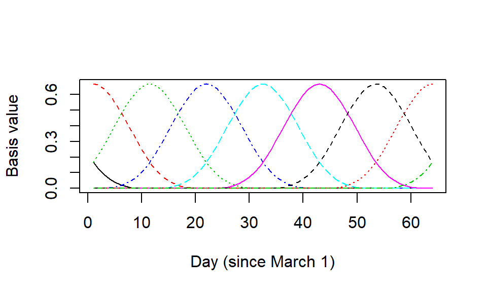

Assuming a vector of $\mathbf{q}$ values drawn from a normal distribution with mean 0 and unit variance, the resulting function can look like this:

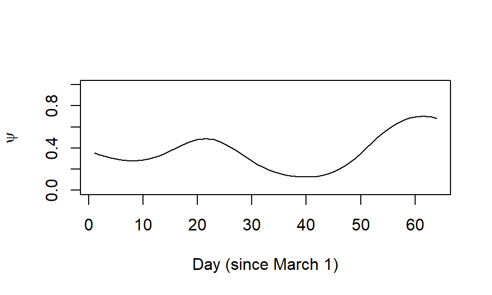

## Fixed parameters

The parameters listed below are fixed at the reported values in the current analysis.

| key | value |
| --- | --- |
| frac_trans_e | 1.20e-01 |
| frac_trans_a | 5.00e-01 |
| frac_trans_c | 2.70e-01 |
| frac_trans_h | 0.00e+00 |
| time_e | 4.00e+00 |
| time_a | 3.50e+00 |
| time_su | 6.00e+00 |
| time_sd | 3.00e+00 |
| time_c | 3.00e+00 |
| time_h | 6.00e+00 |
| max_diag_factor | 2.00e+00 |
| diag_rampup | 1.10e+00 |
| t_half_diag | 2.50e+01 |
| max_detect_frac | 4.00e-01 |
| detect_rampup | 1.10e+00 |
| t_half_detect | 2.50e+01 |
| base_detect_frac | 1.00e-01 |
| frac_asym | 1.80e-01 |
| frac_hosp | 1.20e-01 |
| theta_hosps | 1.00e+01 |
| S_0 | 1.06e+07 |
| E1_0 | 4.00e+01 |
| Ia1_0 | 2.20e+01 |
| Isu1_0 | 9.00e+01 |
| Isd1_0 | 1.40e+01 |
| C1_0 | 2.00e+00 |
| H1_0 | 2.00e+00 |
| R_0 | 0.00e+00 |
| D_0 | 0.00e+00 |
| trend_start | 1.00e+02 |